# Practical Machine Learning: analysis and forecasting of personal activities

ricardoZmestre

19 October 2015

## Introduction

Using devices such as *Jawbone Up, Nike FuelBand, and Fitbit* it is now possible to collect a large amount of data about personal activity relatively inexpensively. These type of devices are part of the quantified self movement – a group of enthusiasts who take measurements about themselves regularly to improve their health, to find patterns in their behavior, or because they are tech geeks. One thing that people regularly do is quantify how much of a particular activity they do, but they *rarely quantify how well they do it*. In this project, the goal will be to use data from accelerometers on the belt, forearm, arm, and dumbell of 6 participants. They were asked to perform barbell lifts correctly and incorrectly in 5 different ways. More information is available from the website [here](http://groupware.les.inf.puc-rio.br/har) (see the section on the Weight Lifting Exercise Dataset).

## Data processing

Data are loaded from [‘pml-training.csv’](https://d396qusza40orc.cloudfront.net/predmachlearn/pml-training.csv) for the trainig data, and [‘pml-testing.csv’](https://d396qusza40orc.cloudfront.net/predmachlearn/pml-testing.csv) for the data from which the predictions have to be built. Note that the latter dataset is only read and used at the end of the report, when final predictions are to be generated.

The default options for reading CSV files in R are accepted: character variables in the file are converted into factors, while numerical variables remain so–although many are transformed into integers, which is in practice irrelevant for the rest of the analysis. Values of ‘NA’, blank space or ‘#DIV/0!’ are read as missing (NA in R). A total of 160 variables are read for 19622 observations.

The data are cleaned in the follwing way: variables with more than 25% of NAs are dropped, together with variables with little variation (as measured by function *nearZeroVar()*) and two numerical variables for time stamps that duplicate information elsewhere in the data. Variables with more than 25% of NAs are dropped because it is risky to do missing-data imputation when there are too many missing values. Note that all variables with missing values have actually considerably more than 25% of values affected, and so the previous step in fact deletes all NAs from the data. It was thus not necessary to do further imputation work.

After the clean-up, 56 variables are left.

Factor representation of some variables are accepted because they seem convenient: they apply to only two variables in the final data set, to user names (of which there are only 6) and to the time stamps (of which there are only 20 different values). In the ensuing analysis, the fact that these variables are factors does not hamper the analysis. (Note that dropping the two variables does not alter results.)

The initial data are split in two sets, a training part and a testing part, in line with the established practice. The split is 60% for training (11776 rows) and 40% for testing (7846 rows). Note that the data over which the final predictions have to be built is not read at this stage. What will be called training and testing data sets below correspond to the split of the initial data set. The models will be assessed using the testing data set, i.e. using data different from the data in the training phase, in order to avoid overfitting.

The analysis will include the usage of alternative models, from which the best one will be chosen. Each alternative model will be estimated also using principal components (PCA) instead of the original variables. The PCA variables are selected such that they explain 90% of the variance of the original variables–19 components are selected. Note that the PCA procedure is only applied to numerical variables but that factor variables are left unaffected in the PCA data set.

## Prediction models

The models used are: linear discriminant analysis (LDA), Classitication Trees (RPART), Naive Bayes (NB), Gradient Boosted Machine (GBM) and Random Forests (RF). Each model is estimated using the *train()* function of the *caret* package, using default options for each model except that cross-validation is used instead of bootstrap: 10-fold cross-validations repeated 3 times were selected. Note that bootstrapping instead of cross-validation led to very similar results.

Each model estimated on the original variables is presented with a description of the model and the outcome of applying it on the testing dataset (which, let me remind, is the 40% portion of the original data set left for testing predictions).

### Linear Discriminant Analysis (LDA)

The first prediction technqiue used is Linear Discriminant Analysis (LDA). The resulting model has an accuracy of 0.752 in the training set (fit) and 0.751 in the testing set.

The corresponding accuracies for the model estimated on the PCA variables are 0.54 in the training set (fit) and 0.542 in the testing set.

This is the outcome of the model.

```
## Linear Discriminant Analysis
##
## 11776 samples
##    54 predictors
##     5 classes: 'A', 'B', 'C', 'D', 'E'
##
## No pre-processing
## Resampling: Cross-Validated (10 fold, repeated 3 times)
## Summary of sample sizes: 10598, 10599, 10600, 10599, 10598, 10599, ...
## Resampling results
##
##   Accuracy   Kappa      Accuracy SD  Kappa SD
##   0.7463481  0.6784967  0.01109569   0.0140772
##
##
```

```
## Confusion Matrix and Statistics
##
##           Reference
## Prediction    A    B    C    D    E
##          A 1961  221  142   90   46
##          B   47  993  126   49  157
##          C  107  201  946  162   89
##          D  117   46  136  961  115
##          E    0   57   18   24 1035
##
## Overall Statistics
##
##                Accuracy : 0.7515
##                  95% CI : (0.7417, 0.761)
##     No Information Rate : 0.2845
##     P-Value [Acc > NIR] : < 2.2e-16
##
##                   Kappa : 0.6847
##  Mcnemar's Test P-Value : < 2.2e-16
##
## Statistics by Class:
##
##                      Class: A Class: B Class: C Class: D Class: E
## Sensitivity            0.8786   0.6542   0.6915   0.7473   0.7178
## Specificity            0.9111   0.9401   0.9137   0.9369   0.9845
## Pos Pred Value         0.7972   0.7238   0.6286   0.6989   0.9127
## Neg Pred Value         0.9497   0.9189   0.9334   0.9498   0.9394
## Prevalence             0.2845   0.1935   0.1744   0.1639   0.1838
## Detection Rate         0.2499   0.1266   0.1206   0.1225   0.1319
## Detection Prevalence   0.3135   0.1749   0.1918   0.1752   0.1445
## Balanced Accuracy      0.8948   0.7971   0.8026   0.8421   0.8511
```

### Classification trees (RPART)

The second prediction technique used is Classification Tree (RPART). The resulting model has an accuracy of 0.535 in the training set (fit) and 0.536 in the testing set.

The corresponding accuracies for the model estimated on the PCA variables are 0.666 in the training set (fit) and 0.658 in the testing set.

This is the outcome of the model.

```
## CART
##
## 11776 samples
##    55 predictors
##     5 classes: 'A', 'B', 'C', 'D', 'E'
##
## No pre-processing
## Resampling: Cross-Validated (10 fold, repeated 3 times)
## Summary of sample sizes: 10598, 10599, 10600, 10599, 10598, 10599, ...
## Resampling results across tuning parameters:
##
##   cp          Accuracy   Kappa       Accuracy SD  Kappa SD
##   0.04188420  0.5363728  0.39790500  0.04171328   0.06178339
##   0.04623477  0.4434121  0.24916341  0.08451235   0.13626073
##   0.11449929  0.3287548  0.06790069  0.03980064   0.06050981
##
## Accuracy was used to select the optimal model using  the largest value.
## The final value used for the model was cp = 0.0418842.
```

```
## Confusion Matrix and Statistics
##
##           Reference
## Prediction    A    B    C    D    E
##          A 2076  787  253  491  121
##          B   14  410   56  163  390
##          C  134  321 1059  632  271
##          D    0    0    0    0    0
##          E    8    0    0    0  660
##
## Overall Statistics
##
##                Accuracy : 0.5359
##                  95% CI : (0.5248, 0.547)
##     No Information Rate : 0.2845
##     P-Value [Acc > NIR] : < 2.2e-16
##
##                   Kappa : 0.3973
##  Mcnemar's Test P-Value : NA
##
## Statistics by Class:
##
##                      Class: A Class: B Class: C Class: D Class: E
## Sensitivity            0.9301  0.27009   0.7741   0.0000  0.45770
## Specificity            0.7057  0.90155   0.7904   1.0000  0.99875
## Pos Pred Value         0.5569  0.39690   0.4381      NaN  0.98802
## Neg Pred Value         0.9621  0.83737   0.9431   0.8361  0.89106
## Prevalence             0.2845  0.19347   0.1744   0.1639  0.18379
## Detection Rate         0.2646  0.05226   0.1350   0.0000  0.08412
## Detection Prevalence   0.4751  0.13166   0.3081   0.0000  0.08514
## Balanced Accuracy      0.8179  0.58582   0.7822   0.5000  0.72822
```

### Naive Bayes (NB)

The third prediction technqiue used is Naive Bayes (NB). The resulting model has an accuracy of 0.723 in the training set (fit) and 0.718 in the testing set.

The corresponding accuracies for the model estimated on the PCA variables are 0.495 in the training set (fit) and 0.488 in the testing set.

This is the outcome of the model.

```
## Naive Bayes
##
## 11776 samples
##    55 predictors
##     5 classes: 'A', 'B', 'C', 'D', 'E'
##
## No pre-processing
## Resampling: Cross-Validated (10 fold, repeated 3 times)
## Summary of sample sizes: 10598, 10599, 10600, 10599, 10598, 10599, ...
## Resampling results across tuning parameters:
##
##   usekernel  Accuracy   Kappa     Accuracy SD  Kappa SD
##   FALSE            NaN       NaN          NA           NA
##    TRUE      0.7192636  0.635063  0.02434703   0.03310649
##
## Tuning parameter 'fL' was held constant at a value of 0
## Accuracy was used to select the optimal model using  the largest value.
## The final values used for the model were fL = 0 and usekernel = TRUE.
```

```
## Confusion Matrix and Statistics
##
##           Reference
## Prediction    A    B    C    D    E
##          A 2204  452  445  545  200
##          B   11  909   59    1   98
##          C   15  151  864  111   47
##          D    2    6    0  599   42
##          E    0    0    0   30 1055
##
## Overall Statistics
##
##                Accuracy : 0.7177
##                  95% CI : (0.7076, 0.7276)
##     No Information Rate : 0.2845
##     P-Value [Acc > NIR] : < 2.2e-16
##
##                   Kappa : 0.6327
##  Mcnemar's Test P-Value : < 2.2e-16
##
## Statistics by Class:
##
##                      Class: A Class: B Class: C Class: D Class: E
## Sensitivity            0.9875   0.5988   0.6316  0.46579   0.7316
## Specificity            0.7075   0.9733   0.9500  0.99238   0.9953
## Pos Pred Value         0.5731   0.8432   0.7273  0.92296   0.9724
## Neg Pred Value         0.9930   0.9100   0.9243  0.90454   0.9428
## Prevalence             0.2845   0.1935   0.1744  0.16391   0.1838
## Detection Rate         0.2809   0.1159   0.1101  0.07634   0.1345
## Detection Prevalence   0.4902   0.1374   0.1514  0.08272   0.1383
## Balanced Accuracy      0.8475   0.7861   0.7908  0.72908   0.8635
```

### Gradient Boosting Method (GBM)

The fourth prediction technqiue used is Gradient Boosting Method (GBM). The resulting model has an accuracy of 0.996 in the training set (fit) and 0.992 in the testing set.

This model was not run with PCA variables due to computing problems that prevented finalisation of the estimation process.

This is the outcome of the model.

```
## Stochastic Gradient Boosting
##
## 11776 samples
##    55 predictors
##     5 classes: 'A', 'B', 'C', 'D', 'E'
##
## No pre-processing
## Resampling: Cross-Validated (10 fold, repeated 3 times)
## Summary of sample sizes: 10598, 10599, 10600, 10599, 10598, 10599, ...
## Resampling results across tuning parameters:
##
##   interaction.depth  n.trees  Accuracy   Kappa      Accuracy SD
##   1                   50      0.8262590  0.7794807  0.013427255
##   1                  100      0.8855040  0.8550119  0.012353349
##   1                  150      0.9111196  0.8874210  0.009184149
##   2                   50      0.9219904  0.9012367  0.009894415
##   2                  100      0.9598351  0.9491765  0.005850563
##   2                  150      0.9796207  0.9742226  0.004531384
##   3                   50      0.9556170  0.9438244  0.005676150
##   3                  100      0.9858186  0.9820633  0.003651864
##   3                  150      0.9923292  0.9902986  0.002594775
##   Kappa SD
##   0.017055344
##   0.015642999
##   0.011634042
##   0.012528645
##   0.007405618
##   0.005732168
##   0.007186298
##   0.004618310
##   0.003280831
##
## Tuning parameter 'shrinkage' was held constant at a value of 0.1
##
## Tuning parameter 'n.minobsinnode' was held constant at a value of 10
## Accuracy was used to select the optimal model using  the largest value.
## The final values used for the model were n.trees = 150,
##  interaction.depth = 3, shrinkage = 0.1 and n.minobsinnode = 10.
```

```
## Confusion Matrix and Statistics
##
##           Reference
## Prediction    A    B    C    D    E
##          A 2220    2    0    0    0
##          B   12 1510    2    0    1
##          C    0    5 1356   17    0
##          D    0    1   10 1263    7
##          E    0    0    0    6 1434
##
## Overall Statistics
##
##                Accuracy : 0.992
##                  95% CI : (0.9897, 0.9938)
##     No Information Rate : 0.2845
##     P-Value [Acc > NIR] : < 2.2e-16
##
##                   Kappa : 0.9898
##  Mcnemar's Test P-Value : NA
##
## Statistics by Class:
##
##                      Class: A Class: B Class: C Class: D Class: E
## Sensitivity            0.9946   0.9947   0.9912   0.9821   0.9945
## Specificity            0.9996   0.9976   0.9966   0.9973   0.9991
## Pos Pred Value         0.9991   0.9902   0.9840   0.9859   0.9958
## Neg Pred Value         0.9979   0.9987   0.9981   0.9965   0.9988
## Prevalence             0.2845   0.1935   0.1744   0.1639   0.1838
## Detection Rate         0.2829   0.1925   0.1728   0.1610   0.1828
## Detection Prevalence   0.2832   0.1944   0.1756   0.1633   0.1835
## Balanced Accuracy      0.9971   0.9962   0.9939   0.9897   0.9968
```

### Random Forests (RF)

The fifth and last prediction technqiue used is Random Forest (RF). The resulting model has an accuracy of 1 in the training set (fit) and 0.998 in the testing set.

The corresponding accuracies for the model estimated on the PCA variables are 1 in the training set (fit) and 0.979 in the testing set.

This is the outcome of the model.

```
## Random Forest
##
## 11776 samples
##    55 predictors
##     5 classes: 'A', 'B', 'C', 'D', 'E'
##
## No pre-processing
## Resampling: Cross-Validated (10 fold, repeated 3 times)
## Summary of sample sizes: 10598, 10599, 10600, 10599, 10598, 10599, ...
## Resampling results across tuning parameters:
##
##   mtry  Accuracy   Kappa      Accuracy SD  Kappa SD
##    2    0.9822813  0.9775810  0.003454837  0.004372655
##   39    0.9974243  0.9967420  0.001614892  0.002042752
##   77    0.9962355  0.9952381  0.001663530  0.002104532
##
## Accuracy was used to select the optimal model using  the largest value.
## The final value used for the model was mtry = 39.
```

```
## Confusion Matrix and Statistics
##
##           Reference
## Prediction    A    B    C    D    E
##          A 2232    2    0    0    0
##          B    0 1511    0    0    0
##          C    0    4 1366    6    0
##          D    0    1    2 1280    2
##          E    0    0    0    0 1440
##
## Overall Statistics
##
##                Accuracy : 0.9978
##                  95% CI : (0.9965, 0.9987)
##     No Information Rate : 0.2845
##     P-Value [Acc > NIR] : < 2.2e-16
##
##                   Kappa : 0.9973
##  Mcnemar's Test P-Value : NA
##
## Statistics by Class:
##
##                      Class: A Class: B Class: C Class: D Class: E
## Sensitivity            1.0000   0.9954   0.9985   0.9953   0.9986
## Specificity            0.9996   1.0000   0.9985   0.9992   1.0000
## Pos Pred Value         0.9991   1.0000   0.9927   0.9961   1.0000
## Neg Pred Value         1.0000   0.9989   0.9997   0.9991   0.9997
## Prevalence             0.2845   0.1935   0.1744   0.1639   0.1838
## Detection Rate         0.2845   0.1926   0.1741   0.1631   0.1835
## Detection Prevalence   0.2847   0.1926   0.1754   0.1638   0.1835
## Balanced Accuracy      0.9998   0.9977   0.9985   0.9973   0.9993
```

### Full data estimation with preferred model

| Model | Accuracy | AccuracyLower | AccuracyUpper | Kappa |
| --- | --- | --- | --- | --- |
| LDA | 0.7514657 | 0.7417472 | 0.7609972 | 0.6846982 |
| RPART | 0.5359419 | 0.5248316 | 0.5470254 | 0.3973275 |
| NB | 0.7176905 | 0.7075873 | 0.7276318 | 0.6326955 |
| GBM | 0.9919704 | 0.9897382 | 0.9938245 | 0.9898452 |
| RF | 0.9978333 | 0.9965331 | 0.9987373 | 0.9972594 |

The final model for the prediction exercise is the Random Forest one (RF), as it was the best behaved in the tests described previously. The model is estimated over the entire data set (i.e., without the training and testing split) and run on the original variables and with 39 randomly selected predictors in each step (parameter *mtry*), as selected in the training data step above–running the full parameter tuning exercise for the full data set was found to be too costly in memory and computing terms.

This is the description and outcome of the final model–note that the outcome is calculated over the same data set as used for the estimation, i.e. it is the fit of the model.

```
##
## Call:
##  randomForest(x = df[predictors], y = df$classe, mtry = 39, importance = TRUE)
##                Type of random forest: classification
##                      Number of trees: 500
## No. of variables tried at each split: 39
##
##         OOB estimate of  error rate: 0.14%
## Confusion matrix:
##      A    B    C    D    E  class.error
## A 5580    0    0    0    0 0.0000000000
## B    1 3794    2    0    0 0.0007900974
## C    0    4 3416    2    0 0.0017533606
## D    0    0    8 3205    3 0.0034203980
## E    0    0    0    8 3599 0.0022179096
```

```
## Confusion Matrix and Statistics
##
##           Reference
## Prediction    A    B    C    D    E
##          A 5580    0    0    0    0
##          B    0 3797    0    0    0
##          C    0    0 3422    0    0
##          D    0    0    0 3216    0
##          E    0    0    0    0 3607
##
## Overall Statistics
##
##                Accuracy : 1
##                  95% CI : (0.9998, 1)
##     No Information Rate : 0.2844
##     P-Value [Acc > NIR] : < 2.2e-16
##
##                   Kappa : 1
##  Mcnemar's Test P-Value : NA
##
## Statistics by Class:
##
##                      Class: A Class: B Class: C Class: D Class: E
## Sensitivity            1.0000   1.0000   1.0000   1.0000   1.0000
## Specificity            1.0000   1.0000   1.0000   1.0000   1.0000
## Pos Pred Value         1.0000   1.0000   1.0000   1.0000   1.0000
## Neg Pred Value         1.0000   1.0000   1.0000   1.0000   1.0000
## Prevalence             0.2844   0.1935   0.1744   0.1639   0.1838
## Detection Rate         0.2844   0.1935   0.1744   0.1639   0.1838
## Detection Prevalence   0.2844   0.1935   0.1744   0.1639   0.1838
## Balanced Accuracy      1.0000   1.0000   1.0000   1.0000   1.0000
```

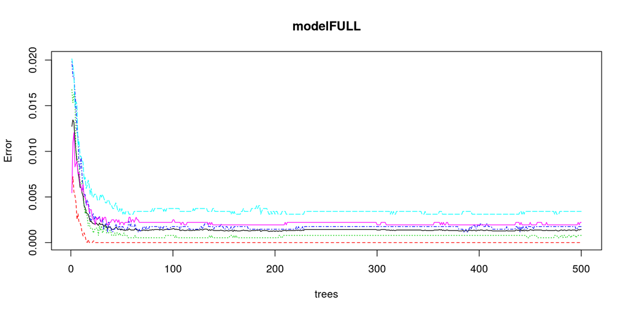

Finally, the chart below shows the list of the most important variables according to the mean reduction in accuracy (left-hand-side panel) and in the Gini index (right-hand-side panel). Surprisingly, the most important one is the variable with the date and time. The rest of the important variables provide information about the most important sensors when it comes to measure how correctly are personal activities performed.

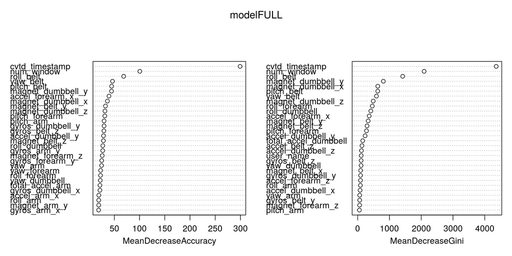

### Data downloading.

Finally, the testing dataset [‘pml-testing.csv’](https://d396qusza40orc.cloudfront.net/predmachlearn/pml-testing.csv) is read and predictions using the final model are produced. They are downloaded using the function *pml_write_files()* as requested.

## Annex

This annex includes a description of the predictor variables in the data set, using function *describe()* in package *Hmisc*.

```
## df[keep]
##
##  56  Variables      19622  Observations
## ---------------------------------------------------------------------------
## user_name
##       n missing  unique
##   19622       0       6
##
##           adelmo carlitos charles eurico jeremy pedro
## Frequency   3892     3112    3536   3070   3402  2610
## %             20       16      18     16     17    13
## ---------------------------------------------------------------------------
## cvtd_timestamp
##       n missing  unique
##   19622       0      20
##
## lowest : 02/12/2011 13:32 02/12/2011 13:33 02/12/2011 13:34 02/12/2011 13:35 02/12/2011 14:56
## highest: 28/11/2011 14:14 28/11/2011 14:15 30/11/2011 17:10 30/11/2011 17:11 30/11/2011 17:12
## ---------------------------------------------------------------------------
## num_window
##       n missing  unique    Info    Mean     .05     .10     .25     .50
##   19622       0     858       1   430.6      44      88     222     424
##     .75     .90     .95
##     644     780     821
##
## lowest :   1   2   3   4   5, highest: 860 861 862 863 864
## ---------------------------------------------------------------------------
## roll_belt
##       n missing  unique    Info    Mean     .05     .10     .25     .50
##   19622       0    1330       1   64.41   -0.20    0.53    1.10  113.00
##     .75     .90     .95
##  123.00  129.00  139.00
##
## lowest : -28.9 -28.8 -28.6 -28.4 -28.3
## highest: 158.0 159.0 160.0 161.0 162.0
## ---------------------------------------------------------------------------
## pitch_belt
##       n missing  unique    Info    Mean     .05     .10     .25     .50
##   19622       0    1840       1  0.3053  -43.60  -42.10    1.76    5.28
##     .75     .90     .95
```

[output cut: 417 more lines]

```
##       n missing  unique    Info    Mean     .05     .10     .25     .50
##   19622       0    1683       1   393.6  -453.0  -153.9   191.0   511.0
##     .75     .90     .95
##   653.0   736.0   799.0
##
## lowest : -973 -966 -964 -963 -962, highest: 1040 1050 1070 1080 1090
## ---------------------------------------------------------------------------
## classe
##       n missing  unique
##   19622       0       5
##
##              A    B    C    D    E
## Frequency 5580 3797 3422 3216 3607
## %           28   19   17   16   18
## ---------------------------------------------------------------------------
```